# Bonanza snowshoe hares: exploratory report

### B. Juvenile Hare Weights

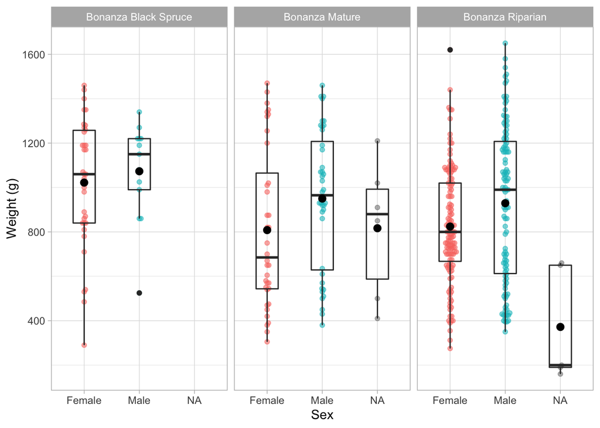

**Figure 2.** Juvenile snowshoe hare weight observations by sex from three trapping sites: Bonanza Black Spruce, Bonanza Mature, and Bonanza Riparian. Red (female), blue (male), and gray (NA) points indicate individual observations for weight (grams) of a juvenile snowshoe hare. Box endpoints indicate the 25<sup>th</sup> and 75<sup>th</sup> percentile values; the black line and black point within the box indicate the median and mean values for each sex, respectively. Data: Kielland et al. (2017)

There were considerably more juvenile snowshoe hares trapped at the Riparian site than the other two sites. On average, the males were larger than the females for each of the trapping sites.

### C. Juvenile Hare Weight Summary

**Table 1.** Descriptive statistics (mean, standard deviation, and sample size) for male and female juvenile snowshoe hares. Data: Kielland et al. (2017)

| Sex | Mean weight (g) | Standard deviation (g) | Sample size (n) |
| --- | --- | --- | --- |
| Female | 855.3909 | 292.2526 | 200 |
| Male | 945.8589 | 333.2151 | 163 |
| NA | 614.5455 | 357.5853 | 15 |

### D. Relationship between weight and hind foot length

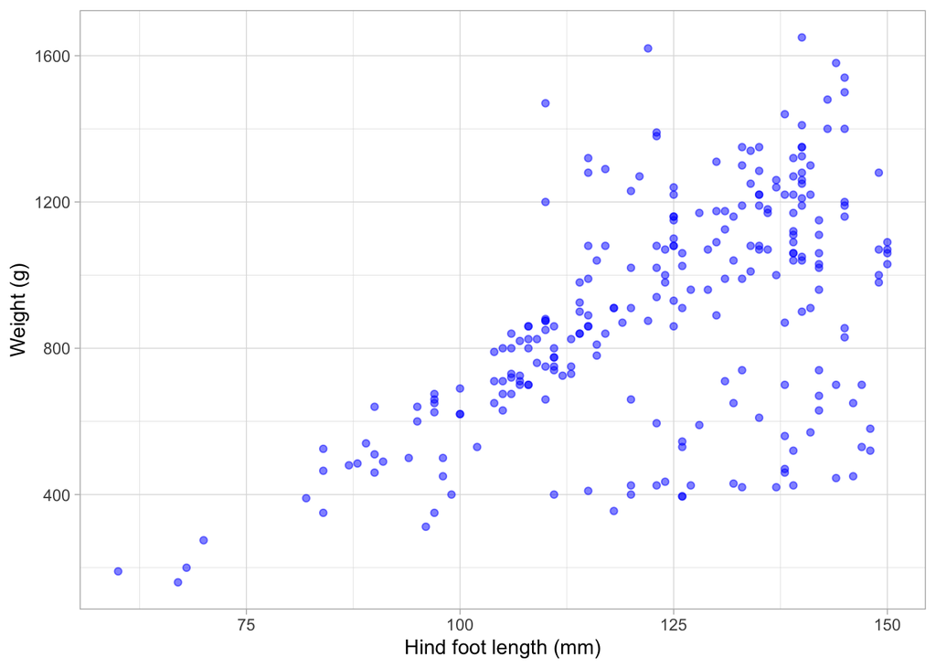

**Figure 3.** Juvenile snowshoe hare weight observations vs. hind foot length observations. Blue points indicate individual observations for weight (grams) and hind foot length (millimeters) of a juvenile snowshoe hare. Data: Kielland et al. (2017)

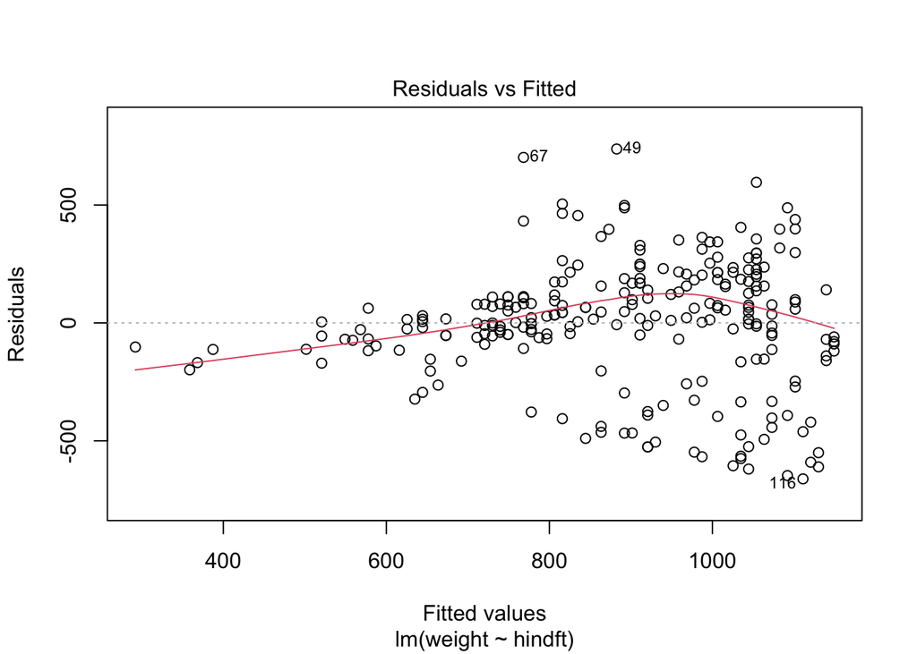

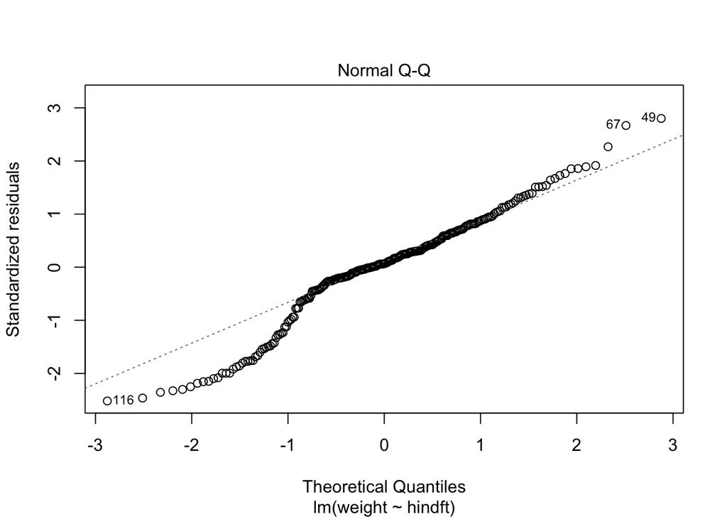

**Figure 4.** Diagnostic plots to test assumptions for linear regression between juvenile snowshoe hare hind foot length and weight. The top plot plot tests for random distribution of residuals to establish homoscedasticity. The bottom plot tests for normal distribution of residuals to establish normality.

The relationship between juvenile snowshoe hare hind foot length and weight appears relatively linear (Figure 3). Simple linear regression revealed that juvenile snowshoe hare hind foot length does not strongly predict juvenile snowshoe hare weight (p < 0.001, R<sup>2</sup> = 0.3) with an average slope of $\beta$ = 9.52 g mm<sup>-1</sup> (i.e., for each one millimeter increase in hind foot length we expect an average increase in weight of 9.52 g). Hind foot length and weight are moderately, and significantly positively correlated (Pearson’s *r* = 0.55, p < 0.001). However, two diagnostic plots (Figure 4) reveal residuals with a non-normal, non-random distribution (heteroscedasticity), which violate the assumptions required for linear regression to be appropriate.

# Summary

# Citations

Kielland, K., F.S. Chapin, R.W. Ruess, and Bonanza Creek LTER. 2017. Snowshoe hare physical data in Bonanza Creek Experimental Forest: 1999-Present ver 22. Environmental Data Initiative. https://doi.org/10.6073/pasta/03dce4856d79b91557d8e6ce2cbcdc14